# SEPA 가격구조 투명성 보고서 — 통과 종목 0

AI 인프라 7개 후보 · 조정주가 기반 사전 스크린과 ‘없음’을 발행하는 규율

저자

Alpha Hunter

공개

2026년 8월 3일

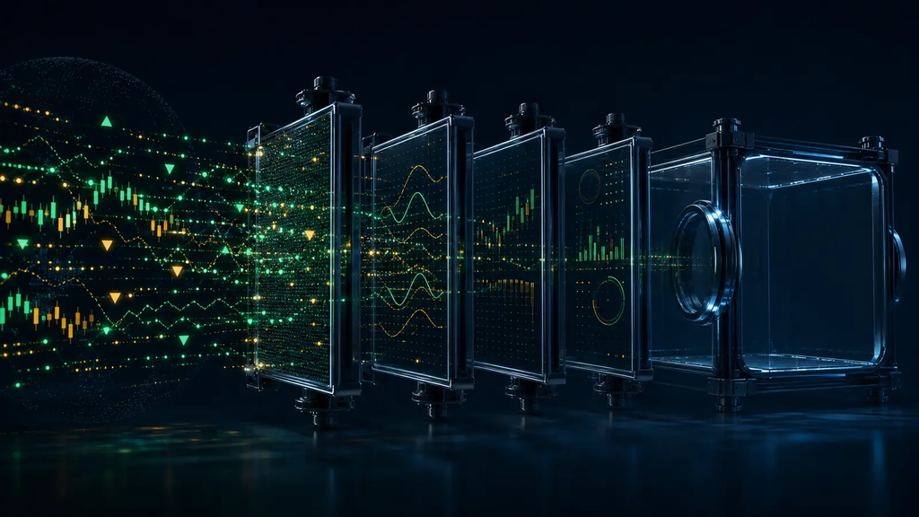

**경고핵심 판정**

2026년 7월 31일 미국장 종가 기준, AI 인프라 후보 7개 가운데 정의한 **가격구조 사전 조건을 모두 통과한 종목은 0개**다. 일곱 종목 모두 현재가가 50일 이동평균 아래에 있다. 이 보고서의 결과는 “살 종목이 없다”가 아니라, **현재 규칙으로 신규 후보를 승인할 근거가 없다**는 뜻이다.

# 1 무엇을 검사했고, 무엇을 검사하지 않았는가

SEPA는 단순 이동평균 세 개로 끝나는 공식이 아니다. 추세 구조, 상대강도, 거래량, 이익과 매출 성장, 산업 내 지위, 촉매를 함께 보는 의사결정 체계다. 이번 보고서는 그중 조정주가만으로 재현 가능한 **가격구조 게이트**를 먼저 검사한다. 따라서 “SEPA 최종 통과”라는 표현 대신 “가격구조 사전 통과”를 사용한다.

가격 기준일은 2026년 7월 31일이다. 2025년 7월 1일부터 기준일까지 Yahoo Finance Chart API가 제공한 일별 조정종가를 내려받아 마지막 50·150·200거래일의 단순평균을 계산했다. 52주 고가와 저가는 마지막 252거래일 조정종가의 최댓값과 최솟값이다. 장중 고가·저가가 아니라 **종가 기준 범위**라는 점에 유의해야 한다.

이번 사전 게이트는 다음 여섯 조건이다.

1. 현재가가 MA50 위에 있을 것
2. 현재가가 MA150 위에 있을 것
3. 현재가가 MA200 위에 있을 것
4. MA150이 MA200 위에 있을 것
5. 현재가가 52주 종가 저점보다 30% 이상 높을 것
6. 현재가가 52주 종가 고점의 75% 이상일 것, 즉 고점 대비 하락이 25% 이내일 것

이것은 완전한 Minervini Trend Template도 아니다. MA200의 최근 상승 여부, MA50과 장기선의 배열, 상대강도 등급을 별도 검증해야 완전한 기술 판정에 가까워진다. 이 글의 목적은 규칙을 부풀리는 것이 아니라, **어떤 필드로 어디까지 판정했는지 경계를 공개**하는 데 있다.

# 2 7개 후보의 계산 결과

| 종목 | 조정종가 | MA50 | MA150 | MA200 | 52주 종가 저점 | 52주 종가 고점 |
| --- | --- | --- | --- | --- | --- | --- |
| VRT | $241.57 | $305.72 | $269.71 | $246.24 | $121.69 | $376.15 |
| FIX | $1,729.69 | $1,817.66 | $1,551.13 | $1,397.41 | $679.82 | $2,066.51 |
| CLS | $331.44 | $360.51 | $332.52 | $327.13 | $181.34 | $472.40 |
| COHR | $262.89 | $347.42 | $289.29 | $254.95 | $86.55 | $426.89 |
| CRDO | $206.99 | $233.84 | $169.39 | $166.05 | $87.81 | $302.52 |
| POWL | $208.68 | $263.97 | $216.11 | $190.55 | $75.68 | $321.94 |
| CIEN | $377.05 | $463.51 | $402.89 | $351.26 | $86.64 | $627.00 |

판정은 위 표시값이 아니라 반올림 전 값으로 수행했다. 경계 사례인 CLS의 원값은 `P=331.44000244140625`, `MA150=332.5178657023112`이고, 가장 근접한 FIX는 `P=1729.68994140625`, `MA50=1817.6637963867188`이다. 전체 고정밀 값과 원시 배열 해시는 감사 스냅샷에 보존했다.

첫 번째 게이트인 MA50에서 전부 탈락한다. 가장 가까운 FIX도 MA50보다 4.8% 낮다. CLS는 8.1%, CRDO는 11.5% 낮고, VRT·POWL은 약 21%, COHR은 24.3% 낮다. “장기 성장 산업”이라는 내러티브와 “지금 가격이 상승 추세 위에 있다”는 판정은 같은 문장이 아니다.

[figure not shown]

FIX가 0.952로 가장 가깝지만 아직 기준선 아래다. ‘거의 통과’를 ‘통과’로 바꾸지 않는 것이 스크린의 역할이다. 출처: Yahoo Finance 조정주가, 조회·계산 2026-08-03.

# 3 통과 행렬: 한 조건이 아니라 구조를 본다

MA50 미통과만으로도 최종 결과는 0개지만, 나머지 조건을 함께 보면 후보들의 손상 위치가 다르다는 사실을 알 수 있다. FIX와 CRDO는 현재가가 MA150·MA200 위이고 장기선 배열도 유지한다. 반면 VRT는 현재가가 세 이동평균 아래다. CLS는 MA150 바로 아래지만 MA200 위이고, COHR·POWL·CIEN은 MA200만 지킨 상태다.

[figure not shown]

FIX는 6개 중 5개를 통과했지만 MA50 아래이므로 최종 미통과다. CRDO는 MA50과 고점 근접성 두 조건이 부족하다.

이 행렬은 두 가지 오류를 막는다. 첫째, “다섯 개나 맞았으니 사실상 통과”라는 조건 완화다. AND 규칙에서는 하나의 실패도 최종 실패다. 둘째, 모든 탈락을 같은 상태로 취급하는 오류다. FIX의 단기 조정과 VRT의 전 이동평균 하회는 복구에 필요한 조건이 다르다.

# 4 52주 범위가 말하는 손상의 깊이

모든 후보는 52주 종가 저점보다 충분히 높다. 이 조건만 보면 강해 보인다. 그러나 고점 대비 거리를 함께 보면 FIX를 제외한 여섯 종목이 모두 고점에서 25% 넘게 내려와 있다. 저점 대비 상승률은 기준점이 낮을수록 크게 보이므로 단독으로 사용하면 회복력을 과장할 수 있다.

[figure not shown]

범위 위치는 `(P−L252)/(H252−L252)`로 계산했다. FIX만 75%선 위에 있고, 나머지는 47.1~55.5%에 모여 있다. 서로 상한이 다른 상승률과 하락률을 같은 막대축에서 직접 비교하지 않는다.

# 5 근접 후보는 추천이 아니라 관찰 가설이다

**FIX**는 이번 구조에서 가장 가까운 후보다. 현재가는 MA150보다 11.5%, MA200보다 23.8% 높고, MA150도 MA200보다 11.0% 높다. 52주 고점 대비 하락도 16.3%로 허용 범위 안이다. 그러나 MA50보다 4.8% 낮다는 사실은 단기 추세가 아직 회복되지 않았음을 뜻한다. 가격이 MA50을 하루 넘었다는 이유만으로 즉시 통과 처리해서도 안 된다. 종가 유지, 거래량, 시장 대비 상대강도, 실적 공시를 다음 단계에서 확인해야 한다.

**CRDO**는 현재가가 MA150·MA200보다 각각 22.2%, 24.7% 높다. 장기 구조는 살아 있지만 MA50보다 11.5% 낮고 52주 고점 대비 31.6% 하락했다. 따라서 “장기선 위”라는 사실만으로 단기 손상이 끝났다고 볼 수 없다.

**CLS**는 MA150보다 불과 0.3% 아래이고 MA200보다 1.3% 위다. 숫자상 경계에 가까워 데이터 공급자의 조정이나 하루 가격 변화로 판정이 바뀔 수 있다. 이런 경계 사례일수록 반올림된 표가 아니라 원시 계산값과 기준일을 보존해야 한다.

이 세 종목을 관찰 목록에 둔다는 말은 매수를 예고한다는 뜻이 아니다. 재검사 비용을 줄이기 위한 우선순위일 뿐이다. 가격구조 게이트가 다시 열려도 펀더멘털·유동성·공시·시장 레짐 검증을 통과하지 못하면 후보는 승인되지 않는다.

# 6 반론: MA50 아래라는 이유만으로 좋은 기업을 버리는가

그럴 수 있다. 이동평균은 후행 지표이고, 급락 뒤 가장 좋은 반등 초입을 놓칠 수 있다. 장기 성장기업은 실적 발표 하나로 MA50을 빠르게 회복할 수도 있다. 그러나 이 스크린의 목표는 모든 상승을 포착하는 것이 아니라 **정의한 추세 구간만 반복적으로 다루는 것**이다. 놓친 수익과 규칙 위반 손실 중 무엇을 관리할지는 전략 설계의 문제다.

또한 후보군 자체에 선택편향이 있다. 일곱 종목은 AI 인프라 내러티브에서 먼저 골랐으므로 전체 미국 시장을 대표하지 않는다. 동일 산업 충격에 함께 노출된 종목끼리 비교하면 “0개 통과”는 개별 기업 문제보다 섹터 조정의 결과일 수 있다. 따라서 이 결과를 시장 전체의 약세로 일반화하지 않는다.

조정주가에도 한계가 있다. 분할과 배당을 반영해 장기 비교에는 유리하지만 실제 체결가격과 다를 수 있고, 공급자가 과거 값을 정정할 수 있다. 재현성을 위해 티커·기준일·조회일·가격 유형·윈도 길이를 함께 기록해야 한다.

# 7 민감도 분석: ‘0개’는 규칙의 함수다

통과 종목 0개라는 결과는 절대적인 기업가치 판정이 아니다. 여섯 조건을 AND로 묶고 각 임계값을 현재처럼 설정했을 때 나오는 결과다. 따라서 투명한 스크린은 최종 숫자뿐 아니라 **어떤 완화가 결과를 바꾸는지**도 보여줘야 한다.

MA50 조건에 5% 완충구간을 허용해 `P/MA50 ≥ 0.95`로 낮추면 FIX의 비율 0.952가 경계 안으로 들어온다. FIX는 나머지 다섯 조건을 이미 통과하므로 전체 결과는 0개에서 1개로 바뀐다. 그러나 이것은 FIX의 가격이 움직인 것이 아니라 분석자가 문턱을 움직인 결과다. 완충구간을 사전에 정의하지 않고 결과를 본 뒤 추가한다면 전형적인 사후 최적화다.

MA50 문턱을 0.90까지 낮추면 CLS도 단기선 조건만 보면 들어오지만, MA150과 고점 근접성에서 여전히 탈락한다. 0.88까지 낮추면 CRDO도 MA50 조건을 넘지만 고점 대비 −31.6% 때문에 최종 탈락한다. 즉 문턱 하나를 완화한다고 후보가 기계적으로 늘어나는 것은 아니다. 통과 행렬이 필요한 이유다.

반대로 고점 근접 조건을 `고점 대비 −35% 이내`로 완화하고 MA50을 `0.85 이상`으로 동시에 낮추면 CRDO가 통과할 수 있다. 두 조건을 한꺼번에 바꿔야 원하는 종목이 등장한다는 사실은 경고 신호다. 결과가 마음에 들지 않을 때 여러 임계값을 조정하면 과거 데이터에는 잘 맞지만 미래 규율은 약해진다.

| 규칙 시나리오 | MA50 문턱 | 고점 문턱 | 전체 통과 |
| --- | --- | --- | --- |
| 기준 규칙 | 1.00 | −25% 이내 | 0개 |
| MA50 5% 완충 | 0.95 | −25% 이내 | FIX 1개 |
| MA50 10% 완충 | 0.90 | −25% 이내 | FIX 1개 |
| 두 문턱 동시 완화 | 0.85 | −35% 이내 | FIX·CRDO 2개 |

이 표의 목적은 완화안을 추천하는 것이 아니다. 전략을 바꾸려면 새 규칙을 다음 관측 이전에 고정하고, 별도 버전으로 충분한 과거 구간과 미사용 구간에서 검증해야 한다. 이번 기준 결과는 그대로 0개로 보존한다.

# 8 데이터 감사 흔적

재현성은 “Yahoo에서 가져왔다”는 문장만으로 확보되지 않는다. 이번 계산에서는 각 종목별로 기준일까지 결측이 아닌 조정종가 **273개**가 존재하는지 확인했다. 이동평균 분모는 각각 정확히 50·150·200개이며, 52주 범위는 마지막 252개 관측치로 잘랐다. 달력 1년과 252거래일은 휴장일 때문에 동일하지 않으므로 혼용하지 않았다.

표의 숫자는 소수 둘째 자리로 표시하지만 판정은 반올림 전 부동소수점 값으로 수행했다. CLS처럼 MA150 경계에 가까운 사례에서 표시값만 비교하면 판정 오류가 생길 수 있기 때문이다. 또한 `Close`와 `Adj Close`를 섞지 않았다. 다음 재실행 때 공급자 정정으로 과거 값이 바뀌면 기존 결과를 덮어쓰지 않고 조회일이 다른 새 스냅샷으로 보존하는 것이 맞다.

이 감사 흔적은 차트를 코드청크로 그렸는지, SVG로 그렸는지보다 더 본질적이다. 저널의 시각 언어는 정밀 SVG를 유지하되, 그 좌표와 라벨이 어떤 입력과 계산에서 나왔는지 역추적할 수 있어야 한다.

# 9 다음 재검사 프로토콜

1. 매 거래일 무조건 다시 돌리지 않고, **주 1회 또는 MA50 회복 알림 발생 시** 재계산한다.
2. 가격구조 통과 후에만 최근 분기 매출·EPS 성장과 회사 공식 공시를 확인한다.
3. 거래량 증가가 동반된 MA50 회복인지, 하루짜리 갭인지 구분한다.
4. S&P 500과 산업 ETF 대비 상대강도를 같은 기준일로 계산한다.
5. 최종 후보가 생겨도 진입·무효화 규칙은 별도 문서에서 사전에 정의한다.

# 10 데이터 출처와 재현 메모

**노트최종 결론**

이번 결과의 정보는 종목명이 아니라 **규칙을 지켰다는 기록**에 있다. 통과 종목 0개를 그대로 발행하면 다음 주의 판정과 비교할 수 있다. 빈칸을 억지 추천으로 채우면 스크린은 분석 도구가 아니라 서사를 합리화하는 장치가 된다.

이 문서는 연구용 가상 스크린이며 투자자문이 아니다. 목표주가와 매수·매도 지시를 제시하지 않는다.